# Optimal solution for the wine quality data

# Aim

The following notebook shows an optimal solution for the final exam task to explore the (simplified) wine dataset, and to build a linear regression model. In the original task I did not specify that you need to find the *best* linear model, so any model would do. However, to find the best model, you need to do something similar to this notebook.

# Read data

```r
wine_df <- read_csv("datasets/wines.csv")
```

# EDA

First, we will explore the dataset. We are looking for anomalies in the data (extreme values), and association between variables (to get hints for model building, and explore multicollinearity).

## Explore outliers

None of the outliers seem to be so extreme to suspect faulty data.

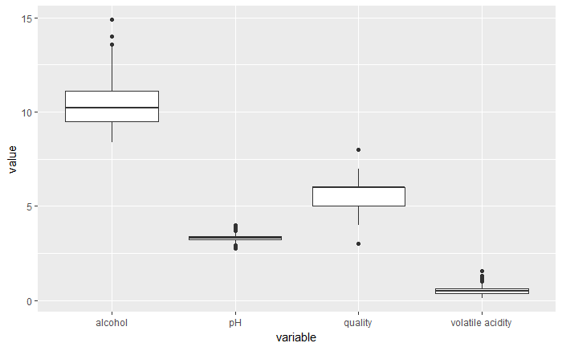

```r
gather(wine_df, variable, value) %>%
   ggplot() +
   aes(x = variable, y = value) +
   geom_boxplot()
```

## Explore correlations and distributions

It seems like there is no huge multicollinearity in the data, but all other variables seem to be associated with quality to some extent. *Make sure to include all variables (even the outcome variable).*

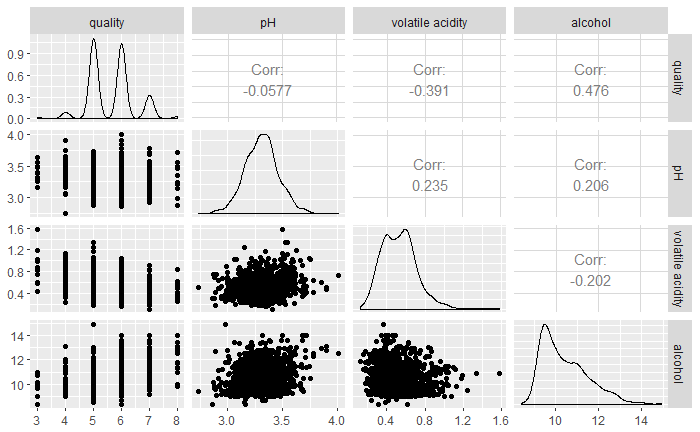

```r
GGally::ggpairs(wine_df) %>%
    print(progress = F)
```

## Building a linear regression model

### Null model for the worst possible fit (the maximum variance in the outcome variable)

You could skip this step, because when you check the significance of the full model (or any linear model), the summary already shows the comparison with the null model (the model F and p values). However I think it is best to see how the model selection is done from the beginning. *Note that the null model does not have model F and p values, as there is nothing to compare to.*

```r
wine_null <- lm(quality ~ 1, data = wine_df)
summary(wine_null)
```

```
Call:
lm(formula = quality ~ 1, data = wine_df)

Residuals:
   Min     1Q Median     3Q    Max
-2.636 -0.636  0.364  0.364  2.364

Coefficients:
            Estimate Std. Error t value Pr(>|t|)
(Intercept)   5.6360     0.0202   279.1   <2e-16 ***
---
Signif. codes:  0 ‘***’ 0.001 ‘**’ 0.01 ‘*’ 0.05 ‘.’ 0.1 ‘ ’ 1

Residual standard error: 0.8076 on 1598 degrees of freedom
```

# Full model with every variable and interactions included

We create a model including all variables with main effects and all interactions. We can start with this as we don’t have a hypothesis.  
*Note that if we include everything, none of the terms are significant because of the suppressor effect.*

```r
wine_full <- lm(quality ~ pH * `volatile acidity` * alcohol , data = wine_df)
summary(wine_full)
```

```
Call:
lm(formula = quality ~ pH * `volatile acidity` * alcohol, data = wine_df)

Residuals:
     Min       1Q   Median       3Q      Max
-2.64497 -0.40500 -0.08077  0.46319  2.22459

Coefficients:
                              Estimate Std. Error t value Pr(>|t|)
(Intercept)                    -1.4857    10.2140  -0.145    0.884
pH                              1.2867     3.0901   0.416    0.677
`volatile acidity`              2.9272    19.5359   0.150    0.881
alcohol                         0.8525     0.9437   0.903    0.366
pH:`volatile acidity`          -1.2206     5.8606  -0.208    0.835
pH:alcohol                     -0.1550     0.2847  -0.545    0.586
`volatile acidity`:alcohol     -0.3625     1.8277  -0.198    0.843
pH:`volatile acidity`:alcohol   0.1049     0.5461   0.192    0.848

Residual standard error: 0.6657 on 1591 degrees of freedom
Multiple R-squared:  0.3234,    Adjusted R-squared:  0.3204
F-statistic: 108.6 on 7 and 1591 DF,  p-value: < 2.2e-16
```

```r
glance(wine_full)
```

| r.squared | adj.r.squared | sigma | statistic | p.value | df | logLik | AIC | BIC | deviance | df.residual |
| --- | --- | --- | --- | --- | --- | --- | --- | --- | --- | --- |
| 0.3233945 | 0.3204176 | 0.6657343 | 108.6349 | 3.479434e-130 | 8 | -1614.296 | 3246.592 | 3294.986 | 705.1346 | 1591 |

Still, the full model is much better then the null. We should explore which terms (variables) are not needed in the model.

```r
anova(wine_null, wine_full)
```

```
Analysis of Variance Table

Model 1: quality ~ 1
Model 2: quality ~ pH * `volatile acidity` * alcohol
  Res.Df     RSS Df Sum of Sq      F    Pr(>F)
1   1598 1042.17
2   1591  705.13  7    337.03 108.63 < 2.2e-16 ***
---
Signif. codes:  0 ‘***’ 0.001 ‘**’ 0.01 ‘*’ 0.05 ‘.’ 0.1 ‘ ’ 1
```

## Model selection

Since we are psychologists and have no knowledge of the wine industry, our analysis is going to be exploratory. We are going to use the backward elimination process, removing terms sequentially from the model, starting with the most complex interactions, and all the way down to the main effects. This means 3 levels: 1) the 3-way interaction (pH:volatile acidity:alcohol), 2) the 2-way interactions: pH:volatile acidity, pH:alcohol, volatile acidity:alcohol, and 3) the main effects: pH, volatile acidity, alcohol.

We are going to compare reduced models to the most plausible model of the previous level.  
First, our best guess is the full model, because we saw previously that it is much better then the null model. However, the model is not optimal, because none of the terms are significant predictors (because of the suppressor effect). Let’s see what happens when we remove the most complex (3-way) interaction.

```r
wine_best <- wine_full
wine_i3 <- update(wine_full, .~. - pH:`volatile acidity`:alcohol)
anova(wine_best, wine_i3)
```

```
Analysis of Variance Table

Model 1: quality ~ pH * `volatile acidity` * alcohol
Model 2: quality ~ pH + `volatile acidity` + alcohol + pH:`volatile acidity` +
    pH:alcohol + `volatile acidity`:alcohol
  Res.Df    RSS Df Sum of Sq      F Pr(>F)
1   1591 705.13
2   1592 705.15 -1 -0.016362 0.0369 0.8477
```

```r
wine_best <- wine_i3
```

It turns out that the 3-way interaction is not needed (does not have a better model fit). Now the best model that we can come up with is the one without the 3-way interaction.

Now we check the 2-way interactions separately.

```r
wine_i2_1 <- update(wine_best, .~. - pH:`volatile acidity`)
wine_i2_2 <- update(wine_best, .~. - pH:alcohol)
wine_i2_3 <- update(wine_best, .~. - `volatile acidity`:alcohol)
anova(wine_best, wine_i2_1)
```

```
Analysis of Variance Table

Model 1: quality ~ pH + `volatile acidity` + alcohol + pH:`volatile acidity` +
    pH:alcohol + `volatile acidity`:alcohol
Model 2: quality ~ pH + `volatile acidity` + alcohol + pH:alcohol + `volatile acidity`:alcohol
  Res.Df    RSS Df Sum of Sq      F Pr(>F)
1   1592 705.15
2   1593 705.16 -1  -0.01124 0.0254 0.8735
```

```r
anova(wine_best, wine_i2_2)
```

```
Analysis of Variance Table

Model 1: quality ~ pH + `volatile acidity` + alcohol + pH:`volatile acidity` +
    pH:alcohol + `volatile acidity`:alcohol
Model 2: quality ~ pH + `volatile acidity` + alcohol + pH:`volatile acidity` +
    `volatile acidity`:alcohol
  Res.Df    RSS Df Sum of Sq      F Pr(>F)
1   1592 705.15
2   1593 705.75 -1  -0.59937 1.3532 0.2449
```

```r
anova(wine_best, wine_i2_3)
```

```
Analysis of Variance Table

Model 1: quality ~ pH + `volatile acidity` + alcohol + pH:`volatile acidity` +
    pH:alcohol + `volatile acidity`:alcohol
Model 2: quality ~ pH + `volatile acidity` + alcohol + pH:`volatile acidity` +
    pH:alcohol
  Res.Df    RSS Df  Sum of Sq      F Pr(>F)
1   1592 705.15
2   1593 705.16 -1 -0.0055905 0.0126 0.9106
```

```r
wine_best <- lm(quality ~ .+., data = wine_df)
```

It turns out that none of the 2-way interactions increase model fit, so keep only the main effects.  
Last, we also check if removing the main effects would improve the model. It turns out that removing any of the main effects would decrease the the model fit, so we should not remove any of the main effects. So we just keep the last wine_best model as the final. The best model is the one with all main effects, and without any interactions.

```r
wine_m1 <- update(wine_best, .~. - pH)
wine_m2 <- update(wine_best, .~. - alcohol)
wine_m3 <- update(wine_best, .~. - `volatile acidity`)
anova(wine_best, wine_m1) # Removing this term would harm the model, so keep it!
```

```
Analysis of Variance Table

Model 1: quality ~ pH + `volatile acidity` + alcohol + (pH + `volatile acidity` +
    alcohol)
Model 2: quality ~ `volatile acidity` + alcohol
  Res.Df    RSS Df Sum of Sq      F    Pr(>F)
1   1595 705.84
2   1596 711.80 -1   -5.9515 13.449 0.0002532 ***
---
Signif. codes:  0 ‘***’ 0.001 ‘**’ 0.01 ‘*’ 0.05 ‘.’ 0.1 ‘ ’ 1
```

```r
anova(wine_best, wine_m2) # Removing this term would harm the model, so keep it!
```

```
Analysis of Variance Table

Model 1: quality ~ pH + `volatile acidity` + alcohol + (pH + `volatile acidity` +
    alcohol)
Model 2: quality ~ pH + `volatile acidity`
  Res.Df    RSS Df Sum of Sq      F    Pr(>F)
1   1595 705.84
2   1596 881.92 -1   -176.08 397.88 < 2.2e-16 ***
---
Signif. codes:  0 ‘***’ 0.001 ‘**’ 0.01 ‘*’ 0.05 ‘.’ 0.1 ‘ ’ 1
```

```r
anova(wine_best, wine_m3) # Removing this term would harm the model, so keep it!
```

```
Analysis of Variance Table

Model 1: quality ~ pH + `volatile acidity` + alcohol + (pH + `volatile acidity` +
    alcohol)
Model 2: quality ~ pH + alcohol
  Res.Df    RSS Df Sum of Sq      F    Pr(>F)
1   1595 705.84
2   1596 779.51 -1   -73.664 166.46 < 2.2e-16 ***
---
Signif. codes:  0 ‘***’ 0.001 ‘**’ 0.01 ‘*’ 0.05 ‘.’ 0.1 ‘ ’ 1
```

## Final model

Let’s check the model fit statistics, R squared, and the predictors. We can also plot the coefficients and their confidence intervals.  
The final model can explain 32% of the variance in quality.

```r
summary(wine_best)
```

```
Call:
lm(formula = quality ~ . + ., data = wine_df)

Residuals:
     Min       1Q   Median       3Q      Max
-2.54671 -0.40614 -0.07843  0.46216  2.21636

Coefficients:
                   Estimate Std. Error t value Pr(>|t|)
(Intercept)         4.26881    0.36898  11.569  < 2e-16 ***
pH                 -0.42187    0.11504  -3.667 0.000253 ***
`volatile acidity` -1.27876    0.09911 -12.902  < 2e-16 ***
alcohol             0.32994    0.01654  19.947  < 2e-16 ***
---
Signif. codes:  0 ‘***’ 0.001 ‘**’ 0.01 ‘*’ 0.05 ‘.’ 0.1 ‘ ’ 1

Residual standard error: 0.6652 on 1595 degrees of freedom
Multiple R-squared:  0.3227,    Adjusted R-squared:  0.3214
F-statistic: 253.3 on 3 and 1595 DF,  p-value: < 2.2e-16
```

```r
glance(wine_best)
```

| r.squared | adj.r.squared | sigma | statistic | p.value | df | logLik | AIC | BIC | deviance | df.residual |
| --- | --- | --- | --- | --- | --- | --- | --- | --- | --- | --- |
| 0.3227132 | 0.3214393 | 0.6652337 | 253.3282 | 1.99379e-134 | 4 | -1615.101 | 3240.202 | 3267.087 | 705.8447 | 1595 |

```r
tidy(wine_best, conf.int = TRUE)
```

| term | estimate | std.error | statistic | p.value | conf.low | conf.high |
| --- | --- | --- | --- | --- | --- | --- |
| (Intercept) | 4.2688118 | 0.36897820 | 11.569279 | 8.778663e-30 | 3.5450786 | 4.9925450 |
| pH | -0.4218653 | 0.11503606 | -3.667244 | 2.532253e-04 | -0.6475031 | -0.1962276 |
| `volatile acidity` | -1.2787589 | 0.09911428 | -12.901863 | 2.683425e-36 | -1.4731668 | -1.0843509 |
| alcohol | 0.3299449 | 0.01654113 | 19.946939 | 3.270705e-79 | 0.2975002 | 0.3623895 |

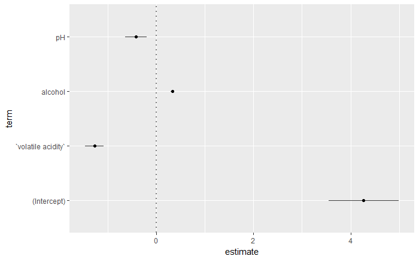

```r
# Show the coefficients on a plot
GGally::ggcoef(wine_best)
```

### Standardised coefficients

```r
# Standardize all variables
wine_std <-
   wine_df %>%
   mutate_all(scale) %>%
   lm(quality ~ .+. , data = .)
summary(wine_std)
```

```
Call:
lm(formula = quality ~ . + ., data = .)

Residuals:
     Min       1Q   Median       3Q      Max
-3.15355 -0.50292 -0.09712  0.57228  2.74448

Coefficients:
                     Estimate Std. Error t value Pr(>|t|)
(Intercept)        -1.354e-15  2.060e-02   0.000 1.000000
pH                 -8.065e-02  2.199e-02  -3.667 0.000253 ***
`volatile acidity` -2.835e-01  2.198e-02 -12.902  < 2e-16 ***
alcohol             4.354e-01  2.183e-02  19.947  < 2e-16 ***
---
Signif. codes:  0 ‘***’ 0.001 ‘**’ 0.01 ‘*’ 0.05 ‘.’ 0.1 ‘ ’ 1

Residual standard error: 0.8237 on 1595 degrees of freedom
Multiple R-squared:  0.3227,    Adjusted R-squared:  0.3214
F-statistic: 253.3 on 3 and 1595 DF,  p-value: < 2.2e-16
```

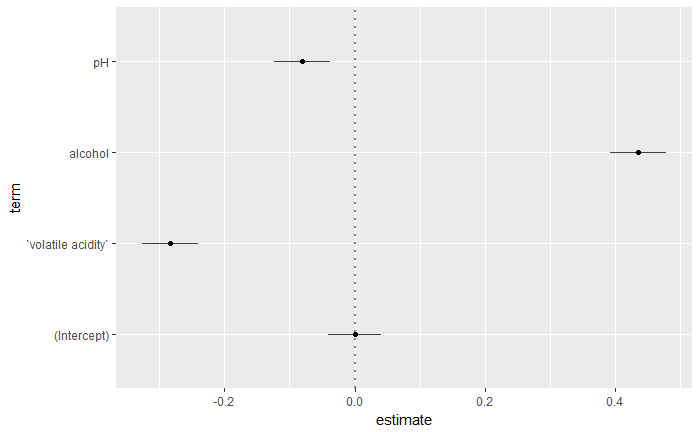

```r
GGally::ggcoef(wine_std)
```

### Plot the predictions

We can create a plot to show the model prediction vs. the outcome

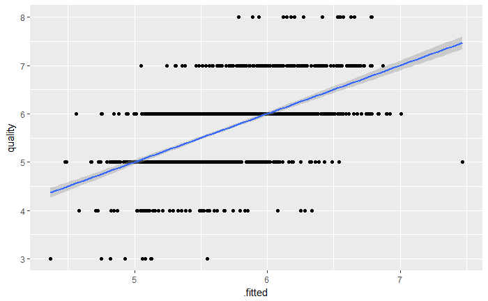

```r
augment(wine_best, wine_df) %>%
   ggplot() +
       aes(y = quality, x = .fitted) +
       geom_point() +
       geom_smooth(method = "lm")
```

### Residual diagnostics

The residuals are not that pretty, as the outcome variable is not continuous. We cannot really do much about that. At least there are no serious outliers and influential cases.

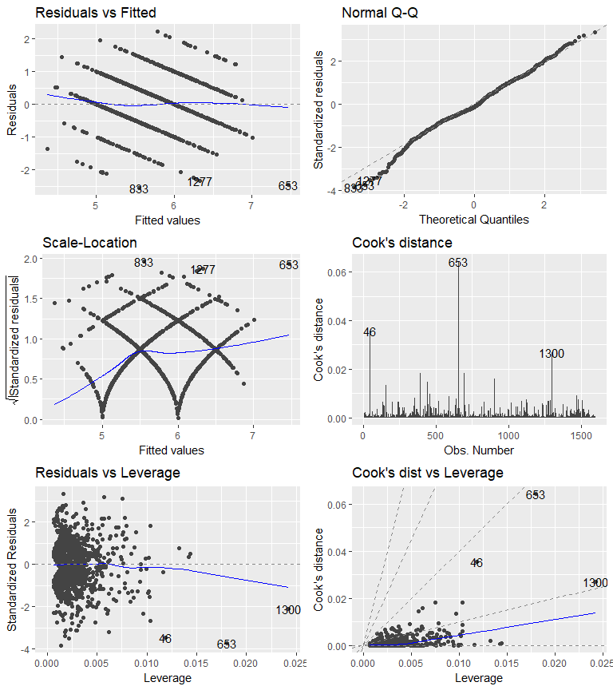

```r
library(ggfortify)
# Residual plots show that there are no outliers or infuential cases in the data
# However the outcome variable is not normally distributed, therefore linear regression might not be the best method to analyze the data
autoplot(wine_best, which = 1:6)
```

### Explore assumptions: multicollinearity and autocorrelation.

```r
car::vif(wine_best)
```

```
                pH `volatile acidity`            alcohol
          1.138976           1.137356           1.122024
```

```r
1/car::vif(wine_best)
```

```
                pH `volatile acidity`            alcohol
         0.8779813          0.8792320          0.8912468
```

```r
car::dwt(wine_best)
```

```
 lag Autocorrelation D-W Statistic p-value
   1        0.129583      1.740827       0
 Alternative hypothesis: rho != 0
```